# MCMC

An introduction with code examples in R

MvO

2019-09-08

# 1 Introduction

This document gives a basic introduction to Markov Chain Monte Carlo sampling (MCMC). MCMC is a method for sampling from a probability distribution p(x). The method is completely generic, it can produce a representative sample from any kind of distribution. So p(x) can be continuous or discrete, univariate or multivariate.

# 2 Monte Carlo sampling

MCMC is a specific subset of Monte Carlo sampling. We begin by demonstrating a sampling method that is MC but not MCMC.

Say we want to sample from a distribution p(x) that is bivariate, and is uniform within the overlapping area of the unit square and the unit circle. We can use MC to sample from that using the following code.

## 2.1 EXAMPLE 1: MC-sampling using Accept-Reject (not MCMC)

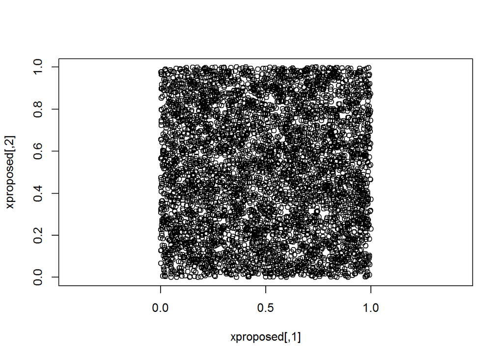

```r
  n         <- 5000
  xproposed <- cbind( runif(n,0,1), runif(n,0,1) )
  plot(xproposed, asp=1)
```

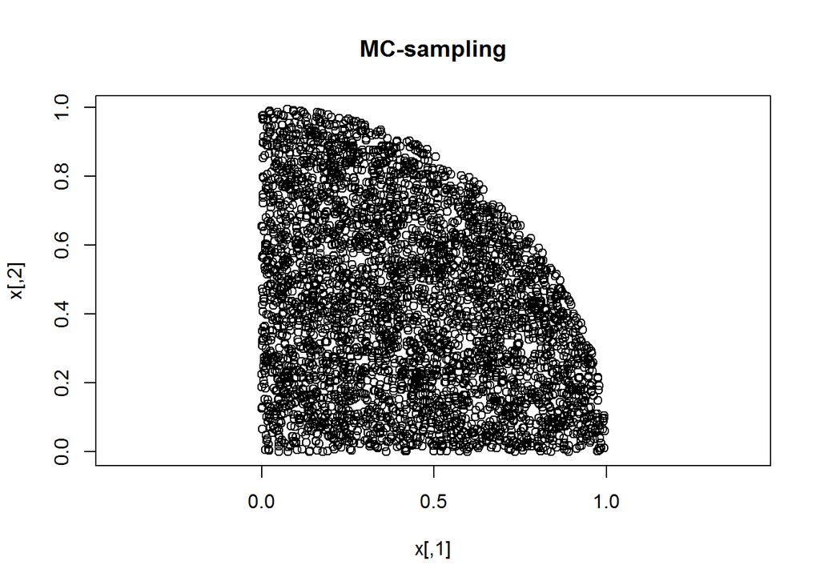

```r
  iaccept   <- xproposed[,1]^2 + xproposed[,2]^2 < 1
  x         <- xproposed[iaccept,]
  plot(x, asp=1,main="MC-sampling")
```

# 3 MCMC

Now we turn to MCMC.

MCMC can be implemented in many different ways. Here we shall only use the oldest and simplest method: the Metropolis algorithm. The method does not require you to have a formula for your distribution (such as a probability density function). Let’s use ‘p(x)’ to denote the distribution that you want to sample from. All you need to know to run the Metropolis algorithm is how to calculate the **ratio** of the p(x) values for any two values of x.

## 3.1 EXAMPLE 2: Same distribution as in EX. 1, now with MCMC

We begin with the same distribution that we already sampled using MC, but this time we sample using MCMC (Metropolis algorithm). So our distribution p(x) is again the bivariate uniform distribution within the overlap of the unit square and the unit circle.

```r
pratio <- function(xa,xb) { (xa[1]^2 + xa[2]^2 < 1)  &&
                            (xa[1]>=0) && (xa[2]>=0) }
# SAMPLING FROM p(x) USING MCMC
  n      <- 2000
  x      <- vector("list",n)
  x[[1]] <- c(0,0)
  for (i in 2:n) {
     xproposed <- x[[i-1]] + runif(2,-1,1)
     if ( runif(1,0,1) < pratio( xproposed, x[[i-1]]) )
        x[[i]] <- xproposed
     else
        x[[i]] <- x[[i-1]]
     end }
x <- do.call(rbind,x)
```

Let’s plot the Markov chain:

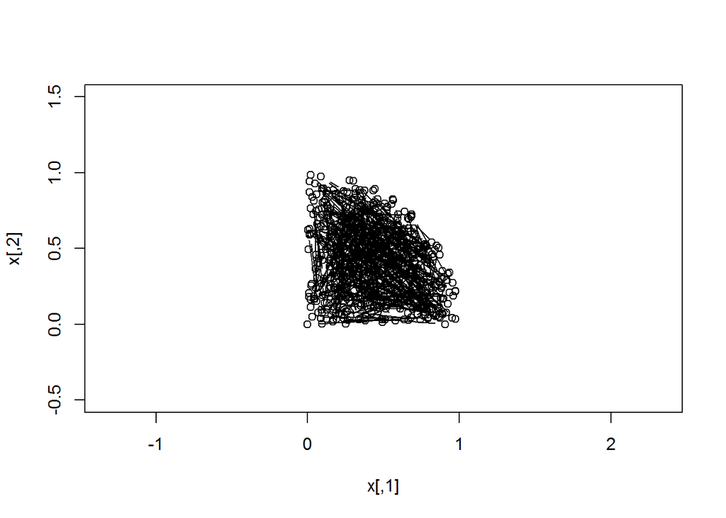

```r
plot( x[ 1: 2,],xlim=c(-0.5,1.5),ylim=c(-0.5,1.5), asp=1,
      xlab="x[,1]", ylab="x[,2]") ; lines(x[1:2,],type="b")
lines(x[ 2: 3,],type="b")
lines(x[ 3: 4,],type="b")
lines(x[ 4: 5,],type="b")
lines(x[ 5: 6,],type="b")
lines(x[ 6: 7,],type="b")
lines(x[ 7: 8,],type="b")
lines(x[ 8: 9,],type="b")
lines(x[ 9:10,],type="b")
lines(x[10:11,],type="b")
lines(x[11:12,],type="b")
lines(x[12:13,],type="b")
lines(x[13:14,],type="b")
lines(x[14:15,],type="b")
lines(x[15:16,],type="b")
lines(x[16:17,],type="b")
lines(x[17:18,],type="b")
lines(x[18:19,],type="b")
lines(x[19:20,],type="b")
for(i in 21:n) { lines(x[(i-1):i,],type="b") }
```

We see that the MCMC gives the same result as the MC.

## 3.2 EXAMPLE 3 Univariate distribution

We now turn to a distribution where the ratio is more complicated.

```r
pratio <- function(xa,xb) { exp(xb^2-xa^2) }
# SAMPLING FROM p(x) USING MCMC
  n      <- 5000
  x      <- vector("list",n)
  x[[1]] <- 0
  for (i in 2:n) {
     xproposed <- x[[i-1]] + runif(1,-1,1)
     if ( runif(1,0,1) < pratio( xproposed, x[[i-1]]) )
        x[[i]] <- xproposed
     else
        x[[i]] <- x[[i-1]]
     end }
x <- do.call(rbind,x)
```

```r
par(mfrow=c(2,2))

plot(x,type="b")
hist(x) ; print(mean(x)) ; print(sd(x))
```

```
## [1] -0.02070537
```

```
## [1] 0.7015691
```

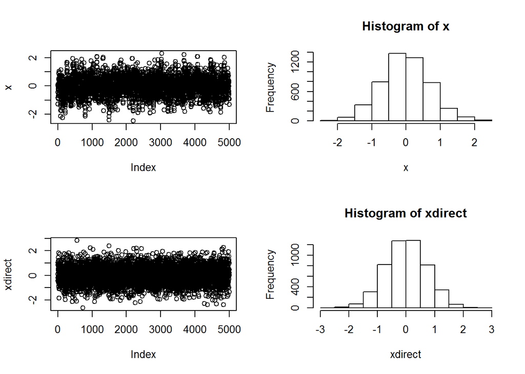

```
## [1] 0.00590558
```

```
## [1] 0.7089796
```

```r
# In this case, R could have given the answer directly
xdirect <- rnorm(n,0,0.7)
plot(xdirect)
hist(xdirect) ; print(mean(xdirect)) ; print(sd(xdirect))
```

## 3.3 EXAMPLE 4: Bivariate distribution

```r
pratio <- function(xa,xb) { exp(xb[1]^2-xa[1]^2) * exp(xb[2]^2-xa[2]^2) }
# SAMPLING FROM p(x) USING MCMC
  n      <- 2000
  x      <- vector("list",n)
  x[[1]] <- c(0,0)
  for (i in 2:n) {
     xproposed <- x[[i-1]] + runif(2,-1,1)
     if ( runif(1,0,1) < pratio( xproposed, x[[i-1]]) )
        x[[i]] <- xproposed
     else
        x[[i]] <- x[[i-1]]
     end }
x <- do.call(rbind,x)
```

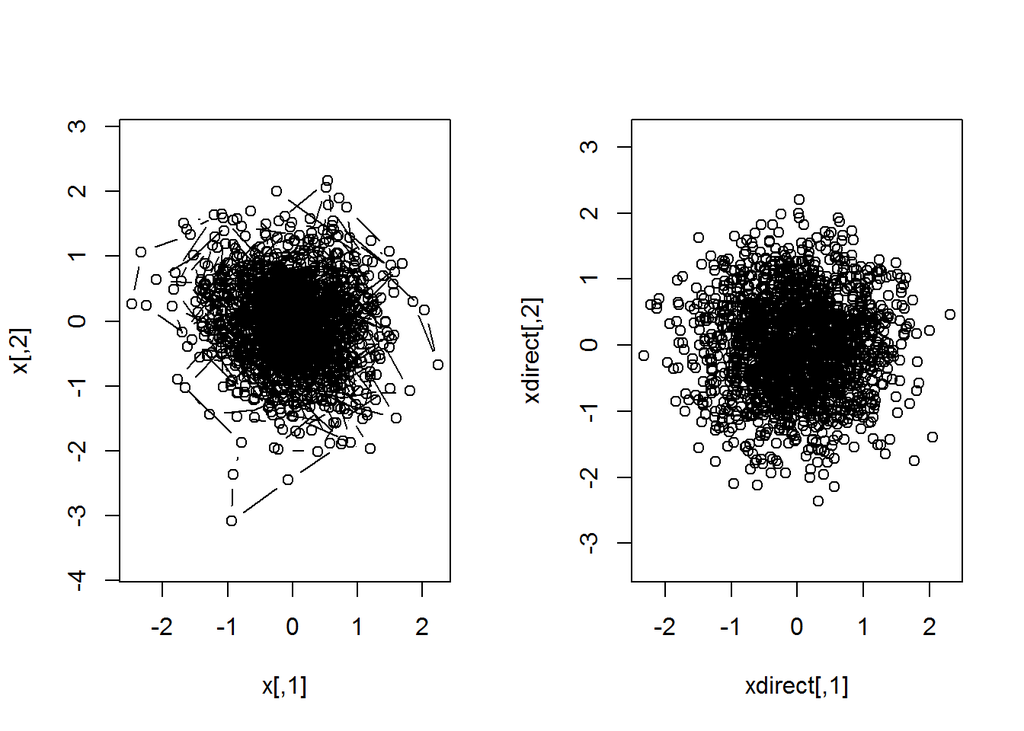

```r
par( mfrow=c(1,2) )

plot(x,asp=1,type="b")
# In this case too, R could have given the answer directly
require(mvtnorm) ; xdirect <- rmvnorm( n, c(0,0), diag(c(0.5,0.5)) )
plot(xdirect,asp=1)
```

## 3.4 EXAMPLE 5: Disjoint distribution

We now show that MCMC can sample from multimodal distributions, even when the modal regions are separated by a region of zero-probability.

- p(x): bivariate, disjoint, unknown distribution on the real number plane
- p(xa)/p(xb) = (xa[1]^2 + xa[2]^2 < 1) || ((xa[1]-2)^2 + (xa[2]-0.5)^2 < 0.5)
- MCMC-sampling from p(x) using Metropolis

```r
pratio <- function(xa,xb) {  (xa[1]   ^2 +  xa[2]     ^2 < 1  ) ||
                            ((xa[1]-2)^2 + (xa[2]-0.5)^2 < 0.5)    }
# SAMPLING FROM p(x) USING MCMC
  n      <- 2000
  x      <- vector("list",n)
  x[[1]] <- c(0,0)
  for (i in 2:n) {
     xproposed <- x[[i-1]] + runif(2,-1,1)
     if ( runif(1,0,1) < pratio( xproposed, x[[i-1]]) )
        x[[i]] <- xproposed
     else
        x[[i]] <- x[[i-1]]
     end }
x <- do.call(rbind,x)
```

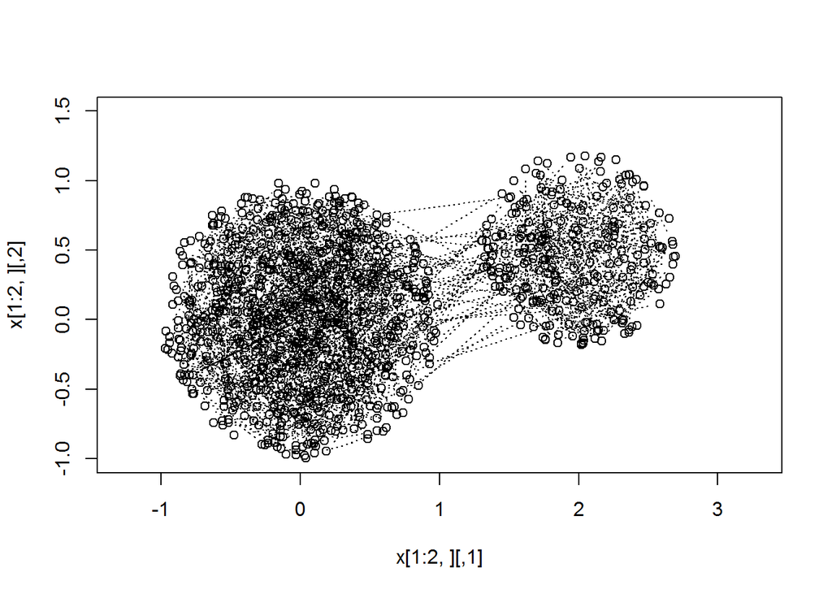

```r
par( mfrow=c(1,1) )
plot(x[1:2,],xlim=c(-1,3),ylim=c(-1,1.5),asp=1) ; lines(x[1:2,],type="b")
for(i in 3:n) { lines(x[(i-1):i,],type="b",lty=3) }
```

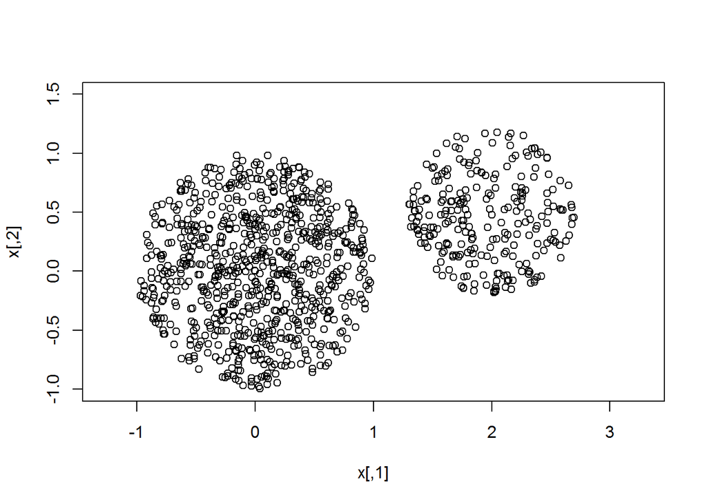

```r
plot(x,xlim=c(-1,3),ylim=c(-1,1.5),asp=1)
```

# 4 Bayesian regression

## 4.1 Why is MCMC so useful for Bayesian modelling?

Bayes’ Theorem tells us how to use data D to change a prior into a posterior: p(x|D) = p(x) p(D|x) / p(D). There is usually no problem specifying a prior p(x) and a likelihood function L(x) = p(D|x). But we usually do not know what p(D) is. So we cannot write down the formula for the posterior. But we can still use MCMC because the troublesome p(D) terms cancel out in the ratio p(xa|D) / p(xb|D) for any pair of points xa and xb in parameter space. The ratio of posterior probabilities for xa and xb is thus the ratio of “prior times likelihood” for xa and xb:

p(xa|D) / p(xb|D) = p(xa) p(D|xa) / (p(xb) p(D|xb)).

Because that posterior ratio is usually known for any pair of points, MCMC can be used to sample from posterior distributions.

## 4.2 Bayesian linear regression

We begin by getting our data, defining our likelihood function, model and prior, and the settings of the MCMC that we are going to do.

```r
require(mvtnorm)
chainLength <- 20000
data <- matrix( c(10,  6.09, 1.83,
                  20,  8.81, 2.64,
                  30, 10.66, 3.27),
                nrow=3, ncol=3, byrow=T) ; nd <- nrow(data)
Li   <- function( model, theta, data, i ) {
          dnorm( (model(data[i,1],theta)-data[i,2])/data[i,3] ) }
L    <- function( model, theta, data    ) {
          prod( sapply(1:nd,function(i){Li(model,theta,data,i)}) ) }
logL <- function( model, theta, data  ) { log(L(model,theta,data)) }
# We define a function 'model' that is the straight line:
model       <- function (x,theta) { theta[1]*x + theta[2] }
np           <- 2
prior        <- matrix( c(0, 1,
                          0,10), nrow=np, byrow=T )
pMin         <- prior[,1] ; pMax <- prior[,2]
pVector      <- rowMeans(prior)
pChain       <- matrix(, nrow=chainLength, ncol=np)
pChain[1,]   <- pVector
logPrior0    <- sum( log( dunif(pVector,pMin,pMax) ) )

logL0        <- logL(model,pVector,data)
logLChain    <- matrix(, nrow=chainLength, ncol=1)
logLChain[1] <- logL0

vcovProposal <- diag( ( 0.2*(pMax-pMin) )^2 )
```

Now we are ready to run the MCMC itself.

```r
for (c in 2:chainLength) {
  cint <- min(1000,round(chainLength/10))
  if (c%%cint == 0) cat("Iteration",c,"|",logPrior0,"|",logL0,"\n")
  candidatepVector <- rmvnorm(n=1, mean=pVector, sigma=vcovProposal)
  logPrior1   <- sum(log(dunif(candidatepVector, pMin, pMax)))
  if (!is.na(logPrior1)) {
    logL1    <- logL(model,candidatepVector,data)
    logalpha <- logPrior1 + logL1 - logPrior0 - logL0
    if (log(runif(1, min=0, max=1)) < logalpha) {
      pVector   <- candidatepVector
      logPrior0 <- logPrior1
      logL0     <- logL1                       } }
     pChain[c,]    <- pVector
     logLChain[c,] <- logL0   }
```

```
## Iteration 1000 | -2.302585 | -3.07681
## Iteration 2000 | -2.302585 | -3.433017
## Iteration 3000 | -2.302585 | -2.799318
## Iteration 4000 | -2.302585 | -3.456192
## Iteration 5000 | -2.302585 | -2.839806
## Iteration 6000 | -2.302585 | -3.61687
## Iteration 7000 | -2.302585 | -3.593581
## Iteration 8000 | -2.302585 | -3.601064
## Iteration 9000 | -2.302585 | -3.217335
## Iteration 10000 | -2.302585 | -2.957245
## Iteration 11000 | -2.302585 | -4.34933
## Iteration 12000 | -2.302585 | -3.320609
## Iteration 13000 | -2.302585 | -3.594401
## Iteration 14000 | -2.302585 | -4.032357
## Iteration 15000 | -2.302585 | -2.932987
## Iteration 16000 | -2.302585 | -3.073664
## Iteration 17000 | -2.302585 | -2.995536
## Iteration 18000 | -2.302585 | -3.226634
## Iteration 19000 | -2.302585 | -3.082926
## Iteration 20000 | -2.302585 | -4.376039
```

Let’s examine the MCMC-results.

```r
nAccepted  <- length(unique(logLChain))
acceptance <- (paste(nAccepted, "out of ", chainLength,
                     "candidates accepted ( = ",
                     round(100*nAccepted/chainLength), "%)"))
print(acceptance)
```

```
## [1] "6187 out of  20000 candidates accepted ( =  31 %)"
```

```r
mp        <- colMeans(pChain)                ; print(mp)
```

```
## [1] 0.2307047 4.0160617
```

```r
iMAP      <- match(max(logLChain),logLChain)
MAP       <- pChain[iMAP,]                  ; print(MAP)
```

```
## [1] 0.2351634 3.8075386
```

```r
pCovMatrix<- cov(pChain)                     ; print(pCovMatrix)
```

```
##             [,1]       [,2]
## [1,]  0.01541617 -0.2253066
## [2,] -0.22530657  4.9365041
```

```r
pCorMatrix<- cor(pChain)                     ; print(pCorMatrix)
```

```
##           [,1]      [,2]
## [1,]  1.000000 -0.816725
## [2,] -0.816725  1.000000
```

```r
sp        <- sqrt( diag(pCovMatrix) )       ; print(sp)
```

```
## [1] 0.1241619 2.2218245
```

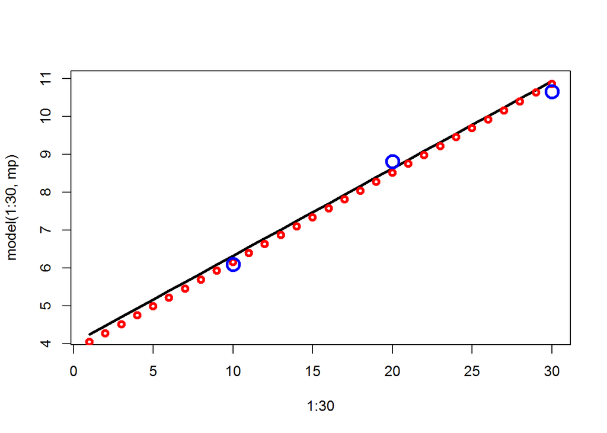

```r
plot  ( 1:30,model(1:30,mp ), col="black",lwd=3,type="l" )
lines ( 1:30,model(1:30,MAP), col="red"  ,lwd=3,type="p" )
points( data                  , col='blue' ,lwd=3,cex=2    )
```

# 5 EXERCISES

All these exercises ask you to modify the MCMC-code for linear regression. We want to keep the original code, so copy the code-chunks to this section (or to a new Rmd-file), and modify that copy.

1. Make the data more informative by reducing the standard deviation by a factor 10. What effects does that have on the Bayesian calibration of the straight-line model?
2. Same question but **increasing** the uncertainty by a factor 10.
3. If you would make the uncertainty about one of the three data points much higher than for the other points, how would that affect the calibration?
4. Modify the code for linear regression: replace the straight line (2 parameters) by a quadratic curve (3 parameters). Can you get the code to work? How would you decide whether the linear or the quadratic curve is the best one? How would you define ‘best’ in a Bayesian way?